# Regionalismo Americano em FHC e Lula

Felipe Rocha

# Informações

Para assegurar que o artigo possa ser apropriadamente replicado, esse arquivo une todos os passos, comandos, arquivos e decisões tomados para analisar os dados e obter os resultados publicados. Em caso de dúvidas ou sugestões, por favor, envie e-mail para: rocha.felipeferreira@gmail.com

# Pacotes e Corpus

Foram utilizados os seguintes comandos no ambiente do RStudio para analisar os dados:

```r
library(quanteda)
library(readtext)
library(tidyverse)
library(gridExtra)
library(reshape2)
library(grid)
library(ggthemes)
library(factoextra)
library(lexiconPT)
```

Quanto ao Corpus, ele foi [desenvolvido](http://www.scielo.br/scielo.php?script=sci_arttext&pid=S0034-73292011000200004) e [disponibilizado](http://www.nadd.prp.usp.br/cis/DetalheBancoDados.aspx?cod=B550&lng=pt-br) por Vilela and Neiva (2011). Basicamente, ele se constitui de dois arquivos txt, cada um deles contêm discursos pronunciados por FHC e por Lula. O seguinte comando foi usado para importar o Corpus:

```r
textos_originais <- readtext("corpus/*.txt", docvarsfrom = "filenames", docvarnames = "Presidente")

corpus_original <- corpus(textos_originais)
docvars(corpus_original, "Total_de_Discursos") <- c(253, 749)
docvars(corpus_original, "Presidente") <- c("FHC", "LULA")
docnames(corpus_original) <- c("FHC", "LULA")
```

Uma vez importado, é fundamental descobrir algumas informações descritivas do Corpus, conforme demonstrado no seguinte comando:

```r
 summary(corpus_original)
```

```
## Corpus consisting of 2 documents:
##
##  Text Types  Tokens Sentences Presidente Total_de_Discursos
##   FHC 24283  457054     18862        FHC                253
##  LULA 42080 1378927     55258       LULA                749
##
## Source: /home/felipe/Documentos/Felipe/Academia/Dados/ARTIGOS/DESENVOLVENDO/Reg americano discursos fhc lula/2 versao anpocs/* on x86_64 by felipe
## Created: Thu Aug 30 16:30:58 2018
## Notes:
```

Uma forma adequada de visualizar as diferenças entre a quantidade de discursos coletados para cada um dos Presidentes é através de gráficos, conforme apresentado abaixo:

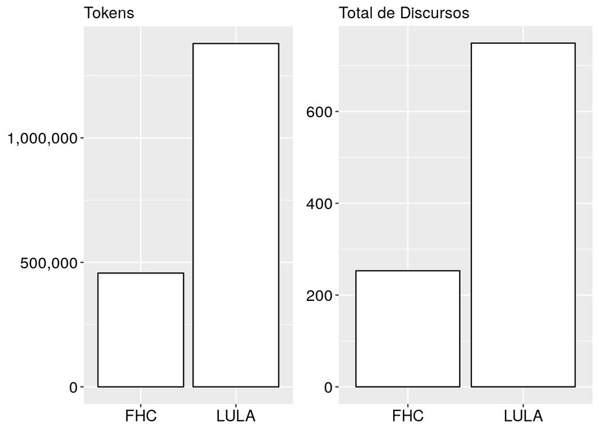

```r
descritivos <- data.frame(summary(corpus_original))

tokens<-ggplot(descritivos, aes(x=Presidente, y=Tokens)) +
  geom_bar(stat = "identity", fill = "white", colour = "black") +
  scale_y_continuous(labels = scales::comma) +
  theme(axis.title = element_blank(),
        axis.text = element_text(size = rel(1.2), colour = "black")) + ggtitle("Tokens")

numero_discursos<-ggplot(descritivos, aes(x=Presidente, y=Total_de_Discursos)) +
  geom_bar(stat = "identity", fill = "white", colour = "black") +
  scale_y_continuous(labels = scales::comma) +
  theme(axis.title = element_blank(),
        axis.text = element_text(size = rel(1.2), colour = "black")) + ggtitle("Total de Discursos")

grid.arrange(tokens, numero_discursos, ncol =2)
```

Fica clara a existência de uma assimetria entre a quantidade de discursos coletada para FHC e para Lula, no sentido em que o primeiro teve muito menos pronunciamentos coletados. Como se vê, ao considerarmos o número de unigramas/palavras (tokens), tem-se 457054 para FHC e 1378927 para Lula.

Semelhantemente, a assimetria se mantem quando se considera o número total de discursos coletados, já que serão analisados 253 discursos de FHC e 749 discursos de Lula. As possíveis explicações para essa diferença podem ser encontradas no artigo. De qualquer modo, para minimizar os efeitos dessa diferença, serão utilizados os valores em escala percentual.

# Quantidade de menções a cada um dos blocos

```r
dicionario.blocos.regionais<-dictionary(list(
  MERCOSUL = c("mercosul", "mercosur", "mercado comum do sul", "mercado común del sur", "common market of the south"),
  ALADI_ALALC = c("aladi", "associação latino-americana de integração", "asociación latinoamericana de integración", "latin american integration association", "alalc", "associação latino-americana de livre comércio", "lafta", " latin american free trade association", "asociación latinoamericana de libre comercio"),
  CARICOM = c("caricom", "comunidade do caribe", "caribbean community", "comunidad del caribe"),
  ALCA = c("alca", "ftaa", "free trade area of the americas", "área de livre comércio das américas", "área de libre comercio de las américas"),
  OEA = c("oea", "oas", "organização dos estados americanos", " organization of american states", "organización de los estados americanos"),
  NAFTA = c("nafta", "north american free trade agreement", "tratado norte-americano de livre comércio", "tlcan", "tratado de libre comercio de américa del norte"),
  CEPAL = c("cepal", "comissão econômica para a américa latina e o caribe", "eclac", "economic comission for latin america and the caribbean", "comisión económica para américa latina y el caribe"),
  CAN_Pacto_Andino = c("comunidade andina", "pacto andino", "comunidad andina", "andean community", "andean pact")))
```

Com esse dicionário, é possível verificar a quantidade de menções de cada um dos blocos regionais para cada Presidente, conforme demonstrado abaixo:

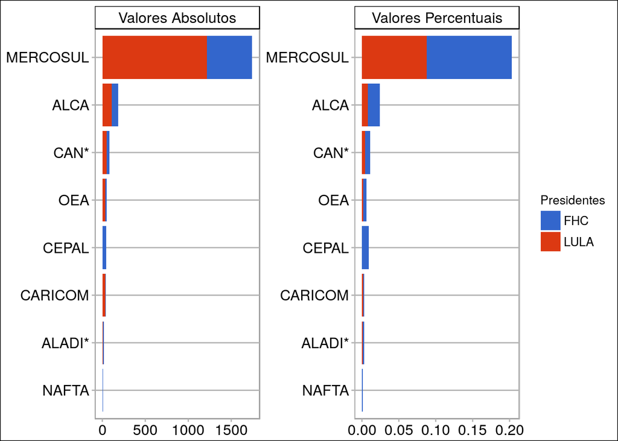

```r
freq_mencoes <- as.data.frame(dfm(corpus_original, dictionary = dicionario.blocos.regionais, tolower = TRUE))

freq_mencoes$Presidentes <- c("FHC", "LULA")
freq_mencoes$document<-NULL
freq_mencoes$Presidentes<-factor(freq_mencoes$Presidentes)
freq_mencoes<-melt(freq_mencoes, id.vars = "Presidentes")
freq_mencoes$Tokens <- ifelse(freq_mencoes$Presidentes == "FHC", 458133, 1382172)
freq_mencoes$Percentual <-freq_mencoes$value/freq_mencoes$Tokens*100
freq_mencoes$Percentual <- round(freq_mencoes$Percentual, digits = 3)
names(freq_mencoes) <- c("Presidentes", "Blocos", "Valores_Absolutos", "Tokens", "Valores_Percentuais")

freq_mencoes$Blocos <- factor(freq_mencoes$Blocos, levels = c("MERCOSUL", "ALCA", "CAN_Pacto_Andino", "OEA", "CEPAL", "CARICOM", "ALADI_ALALC", "NAFTA"), labels = c("MERCOSUL", "ALCA", "CAN*", "OEA", "CEPAL", "CARICOM", "ALADI*", "NAFTA"))

freq_mencoes_gather <- gather(freq_mencoes, key = "Tipo", value = "Valor", -Presidentes, -Blocos, -Tokens)


nomes_faceta = c("Valores_Absolutos" = "Valores Absolutos", "Valores_Percentuais" = "Valores Percentuais")

ggplot(freq_mencoes_gather, aes(x=reorder(Blocos, Valor), y= Valor, fill = Presidentes)) + geom_bar(stat = "identity") + coord_flip() + facet_wrap(~Tipo, scales = "free", labeller = as_labeller(nomes_faceta)) + theme_calc() + theme(axis.title = element_blank(), axis.text = element_text(size = rel(1.2), colour = "black"), strip.text = element_text(size = rel(1.2), colour = "black")) + scale_fill_gdocs()
```

# Cluster dos blocos

Baseado em: - https://sillasgonzaga.github.io/2016-06-28-clusterizacaoPaises/ - http://lincolntneves.weebly.com/blog/anlise-de-cluster-no-r - http://www.sthda.com/english/articles/28-hierarchical-clustering-essentials/92-visualizing-dendrograms-ultimate-guide/

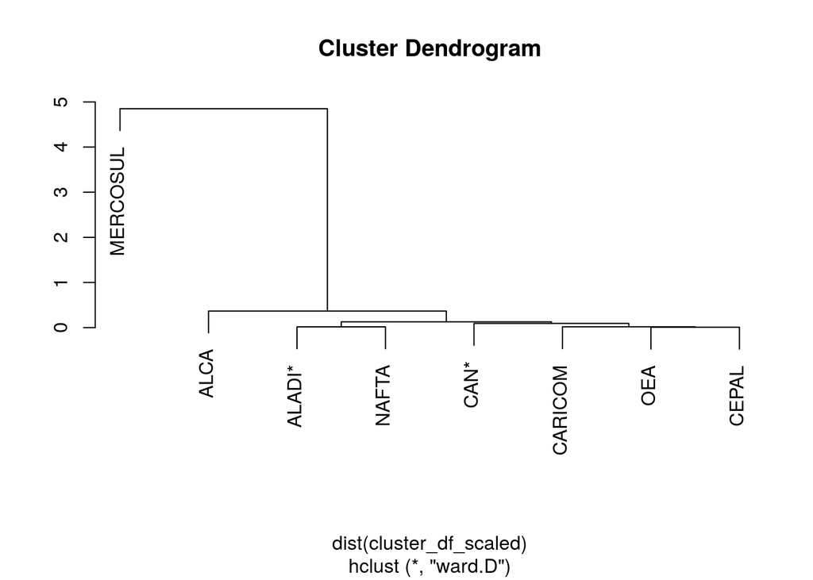

```r
cluster_df <- freq_mencoes %>% group_by(Blocos) %>% summarise(freq = sum(Valores_Absolutos))

cluster_df_scaled <- scale(cluster_df$freq)
rownames(cluster_df_scaled) <- cluster_df$Blocos

cluster_dendograma <- hclust(dist(cluster_df_scaled), method = "ward.D")

plot(cluster_dendograma, labels = cluster_df$Blocos, ylab = "")
```

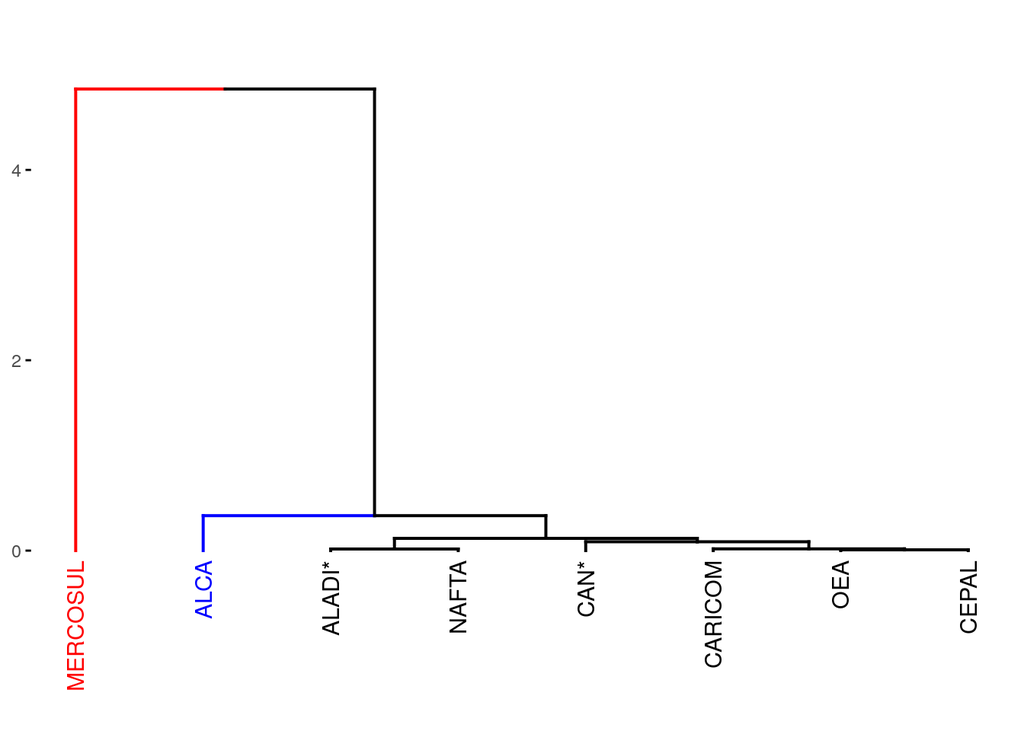

```r
fviz_dend(cluster_dendograma, k = 3, k_colors = c("red", "blue", "black"), ylim = c(-1.4, 5), main = "", ylab = "")
```

# Explorando o Mercosul

Como o Mercosul e o ALCA são os blocos mais mencionados, faremos algumas outras explorações quantitativas antes de analisar qualitativamente os mesmos em conjunto com os outros blocos. Comecemos pelo Mercosul.

```r
mercosul <- tokens(corpus_original)
mercosul <- tokens_keep(mercosul, c("mercosul", "mercosur", "mercado comum do sul", "mercado común del sur", "common market of the south"), case_insensitive = TRUE, window = 8)

mercosul_dfm <- dfm(mercosul, tolower = TRUE, remove_numbers = TRUE, remove_punct = TRUE, remove = c(stopwords("portuguese"), "é", "mercosul", "president*", "y", "senh*", "mercosur", "quer*"))

mercosul_dfm_stemmed <- dfm_wordstem(mercosul_dfm, language = "portuguese")
```

Primeiro, uma básica nuvem de palavras comparativas:

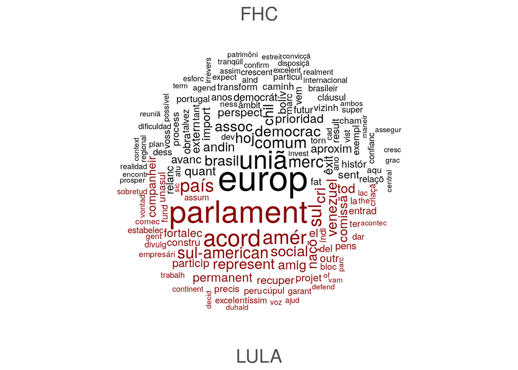

```r
textplot_wordcloud(mercosul_dfm_stemmed, comparison = TRUE, color = c("black", "darkred"), max_words = 150, rotation = .25)
```

Segundo, análise de keyness dos adjetivos:

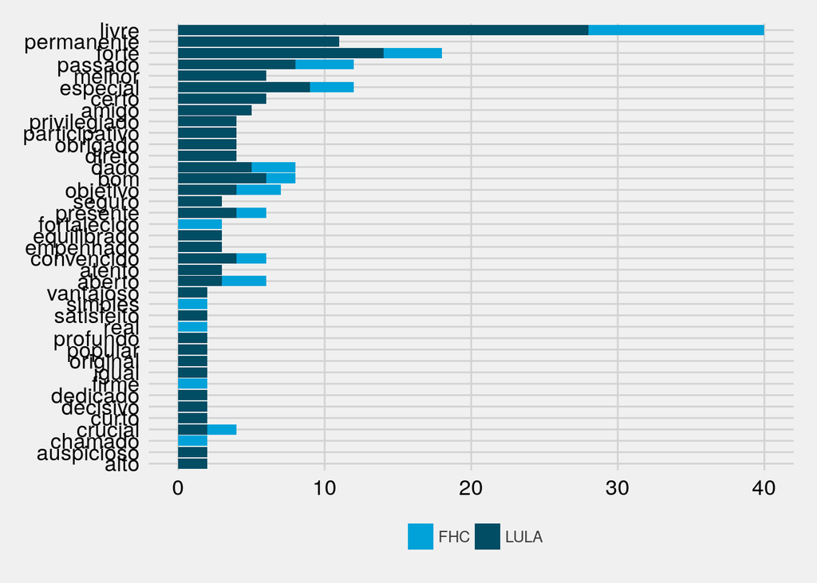

```r
adjetivos <-sentiLex_lem_PT02 %>% filter(grammar_category == "Adj")

mercosul_adj_dfm <- dfm_select(mercosul_dfm, pattern = adjetivos$term)
mercosul_adj_data <- convert(mercosul_adj_dfm, to = "data.frame")
mercosul_adj_data <- gather(mercosul_adj_data, key = "adjetivo", value = "valor", -document)

mercosul_adj_qtd <- mercosul_adj_data %>% filter(valor > 0) %>% group_by(document) %>% count(document)
mercosul_adj_qtd$tot <- c(126, 126)
mercosul_adj_qtd$perc <- mercosul_adj_qtd$n/mercosul_adj_qtd$tot*100
mercosul_adj_qtd$perc <- round(mercosul_adj_qtd$perc, 1)


mercosul_adj_data <- filter(mercosul_adj_data, valor > 1)

ggplot(mercosul_adj_data, aes(x=reorder(adjetivo, valor), y = valor, fill = document)) + coord_flip() + geom_col() + theme_fivethirtyeight() + theme(axis.title = element_blank(), axis.text = element_text(size = rel(1.1), colour = "black")) + scale_fill_economist() + labs(fill="")
```

```r
mercosul.kwic <- tokens(corpus_original)
mercosul.kwic <- kwic(mercosul.kwic, window = 8, case_insensitive = TRUE, pattern = phrase(c("mercosul", "mercosur", "mercado comum do sul", "mercado común del sur", "common market of the south")))

mercosul.kwic <- DT::datatable(mercosul.kwic)
DT::saveWidget(mercosul.kwic, "mercosul.kwic.html")
```

# Explorando o ALCA

Primeiro, uma básica nuvem de palavras comparativas:

```r
alca <- tokens(corpus_original)
alca <- tokens_keep(alca, c("alca", "ftaa", "free trade area of the americas", "área de livre comércio das américas", "área de libre comercio de las américas"), case_insensitive = TRUE, window = 8)

alca_dfm <- dfm(alca, tolower = TRUE, remove_numbers = TRUE, remove_punct = TRUE, remove = c(stopwords("portuguese"), "é", "president*", "y", "senh*", "quer*", "alca", "sobre", "ser", "the", "is", "was", "i"))

alca_dfm_stemmed <- dfm_wordstem(alca_dfm, language = "portuguese")
```

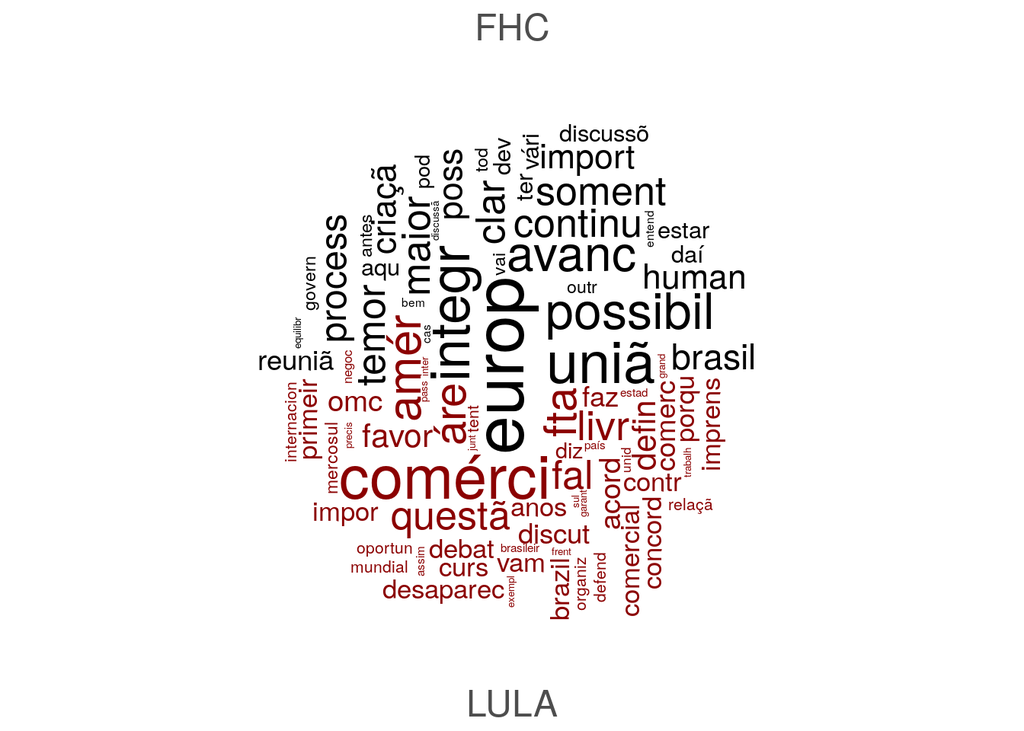

```r
textplot_wordcloud(alca_dfm_stemmed, comparison = TRUE, color = c("black", "darkred"), max_words = 150, rotation = .45)
```

Segundo, análise de adj:

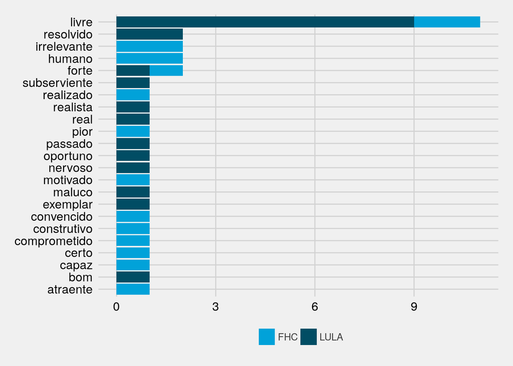

```r
alca_adj_dfm <- dfm_select(alca_dfm, pattern = adjetivos$term)

alca_adj_data <- convert(alca_adj_dfm, to = "data.frame")
alca_adj_data<- gather(alca_adj_data, key = "adjetivo", value = "valor", -document)

alca_adj_qtd <- alca_adj_data %>% filter(valor > 0) %>% group_by(document) %>% count(document)

alca_adj_qtd$tot <- c(25, 25)
alca_adj_qtd$per <- alca_adj_qtd$n/alca_adj_qtd$tot*100


ggplot(alca_adj_data, aes(x=reorder(adjetivo, valor), y=valor, fill = document)) + geom_col() + coord_flip() + theme_fivethirtyeight()  + theme(axis.title = element_blank(), axis.text = element_text(size = rel(1), colour = "black")) + scale_fill_economist() + labs(fill ="")
```

```r
alca.kwic <- tokens(corpus_original)
alca.kwic <- kwic(alca.kwic, window = 8, case_insensitive = TRUE, pattern = phrase(c("alca", "ftaa", "free trade area of the americas", "área de livre comércio das américas", "área de libre comercio de las américas")))

alca.kwic <- DT::datatable(alca.kwic)
DT::saveWidget(alca.kwic, "alca.kwic.html")
```

Por fim, é possível também verificar as similaridades entre FHC e Lula quanto ao MERCOSUL e à ALCA Para tanto:

```r
alca.simil<-textstat_simil(alca_dfm_stemmed, margin = "documents", method = "correlation")
mercosul.simil<-textstat_simil(mercosul_dfm_stemmed, margin = "documents", method = "correlation")
```